# Week 5 Workshop Walkthrough

# 1 The Plan

In this session I’ll lead you through the steps of completing an assignment, similar to your 7CS034 assignment, using a different dataset. I’d like you to follow along with me today and produce the same report that I do. **Do not work on you module assessment** in this session, we won’t help you with that. But, we will help you with producing the report which we are all working on today.

I’ve created a starter file for you and I’ve set some `YAML` settings at the top of the starter file to make it behave the way that I like - feel free to modify the settings yourself to make it behave the way you like it.

# 2 Get the starter files and dataset

On your desktop create a new folder called `Week 5`. Then downoad the following files from [canvas](https://canvas.wlv.ac.uk/courses/41908) and save them inside it.

- `data.csv` the dataset
- `01843621.qmd` my starter file named using the convention outlined in the assessment brief

Launch `RStudio` if you haven’t done so already.

## 2.1 About the Dataset

For the purpose of today’s workshop we are working with the famous [Wisconsin Breast Cancer Dataset](https://archive.ics.uci.edu/dataset/17/breast+cancer+wisconsin+diagnostic). You can find a full description of the dataset at the above link on the [UC Irvine, Machine Learning Repository](https://archive.ics.uci.edu/) which is a great source of datasets for AI and Data Science generally.

Load the necessary packages and libraries first

```r
library(tidyverse)
library(ggplot2)
library(ggthemes)
```

Read the dataset into `Rstudio` as normal

```r
data <- read_csv("data.csv")
```

Note that you’ll need to specify the correct path to where you have saved the data file in order to read the data with `read_csv()`.

Next let’s take a peek at the data to see what we are dealing with.

```r
View(data)
```

The above command let’s us view the dataset within `RStudio`. We can also do

```r
head(data)
```

```
# A tibble: 6 × 32
        id diagnosis radius_mean texture_mean perimeter_mean area_mean
     <dbl> <chr>           <dbl>        <dbl>          <dbl>     <dbl>
1   842302 M                18.0         10.4          123.      1001
2   842517 M                20.6         17.8          133.      1326
3 84300903 M                19.7         21.2          130       1203
4 84348301 M                11.4         20.4           77.6      386.
5 84358402 M                20.3         14.3          135.      1297
6   843786 M                12.4         15.7           82.6      477.
# ℹ 26 more variables: smoothness_mean <dbl>, compactness_mean <dbl>,
#   concavity_mean <dbl>, `concave points_mean` <dbl>, symmetry_mean <dbl>,
#   fractal_dimension_mean <dbl>, radius_se <dbl>, texture_se <dbl>,
#   perimeter_se <dbl>, area_se <dbl>, smoothness_se <dbl>,
#   compactness_se <dbl>, concavity_se <dbl>, `concave points_se` <dbl>,
#   symmetry_se <dbl>, fractal_dimension_se <dbl>, radius_worst <dbl>,
#   texture_worst <dbl>, perimeter_worst <dbl>, area_worst <dbl>, …
```

to check the types of the variables. We can see that `diagnosis` is a variable of type `chr` while the rest are of type `double`. This makes sense since `diagnosis` can take the values

- `B` = benign
- `M` = malignant

In fact, this dataset has been produced to serve as a tool for using the measurements in the other columns to classify cells as cancerous or not. In this sense, there is something immediately of interest here, namely: **what is the relationship between the various measurements in the other columns and whether or not a cell is classified as benign or malignant?** A partial answer to this question could well be the subject of the piece of work we produce today.

# 3 Our Coursework

Now we’ll start working directly on the mock coursework we will prepare today. We’ll work on the introdcution for the next few minutes.

## 3.1 Introduction

General introductory remarks about what we are doing and some references as required.

## 3.2 The Data

We don’t need to give an extensive piece here about the data but we should certainly write something, which we can change/amend later as necessary.

## 3.3 Investigation

This is where we’ll spend most of our time but we’ll only include the interesting stuff in our final report. The first thing I decided to do was to look at possible relationships between the variable in the dataset. One such tool is a **correlation plot** which we can create using the `corrplot` package.

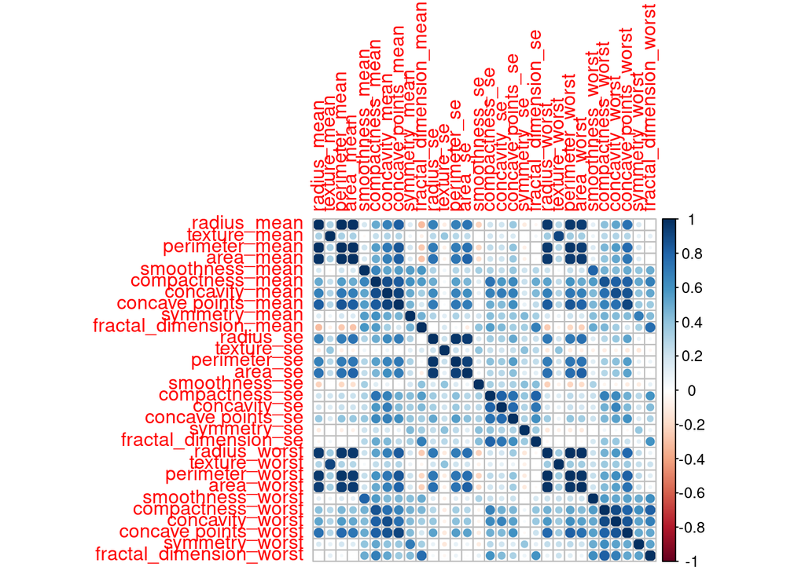

```r
library(corrplot)
M<-data[3:32]
c<-cor(M)
corrplot(c)
```

There is a lot to see here and now we need to think about what this means.

- It might be interesting to create correlation plots only for the benign and malignant cases.
- Can you do that?
- Does that help you to know where to look for something interesting?

## 3.4 When we find something

Once we find something interesting we can plot it and offer an explanation.